# Audição Cognitiva

Jônatas Bertolazzo, Letticia Nicoli, Renato Ramos

22/10/2019

# Análise de texto a partir de arquivos de audio transcritos

### utilizando a plataforma do Watson

Neste trabalho utilizamos a tecnologia “Speech to Text” presente no Watson para transcrever alguns arquivos de áudio que responderam a pergunta “Você acredita que a Inteligência Artificial e os robos irão reduzir as oportunidades de emprego, ‘roubando’ o emprego dos humanos?”.

Com todos os audios transcritos passamos para a etapa de NLP para tentar projetar uma resposta que resuma todo o conteudo contido dentro dos audios.

```r
cps <- tm_map(cps, stripWhitespace)
cps <- tm_map(cps, content_transformer(tolower))
cps <- tm_map(cps, removeNumbers)
```

Depois de fazer este primeiro tratamento podemos ver o estado em que o nosso texto e suas principais palavras se encontram, para isso utilizamos uma plotagem no estilo “Wordcloud”.

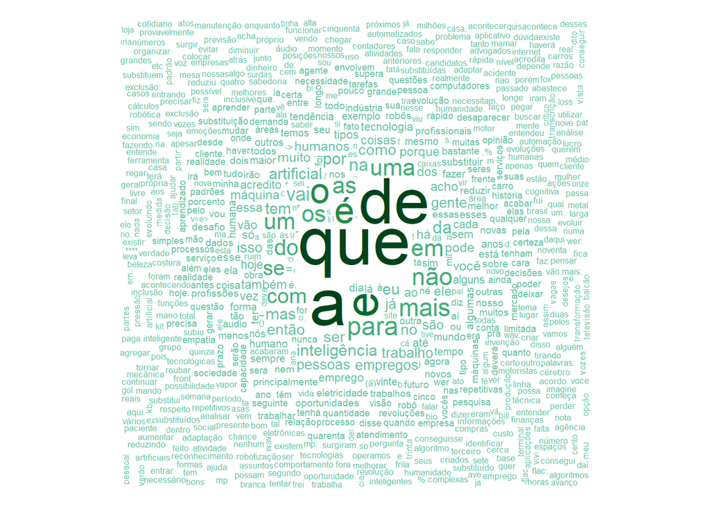

```r
tdm <- TermDocumentMatrix(cps,
                          control = list(wordLengths = c(1, Inf)))

m <- as.matrix(tdm)
word.freq <- sort(rowSums(m), decreasing = T)
pal <- brewer.pal(9, "BuGn")
pal <- pal[-(1:4)]

library(wordcloud)
wordcloud(words = names(word.freq), freq = word.freq, min.freq = 2,
          random.order = F, colors = pal)
```

Podemos ver no gráfico que o nosso texto fica bastante sujeito a palavras que á principio não fazem sentido na nossa análise, como por exemplo a palavras ‘de, que’ e os artigos ‘e, a’.

passamos então para a análise e retirada de Stopwords, começando com a biblioteca padrão de stopwords de palavras em português.

```r
cps <- tm_map(cps, removeWords, stopwords("portuguese"))
```

Utilizamos do processo de TDM para a criação de uma matrix termos para que seja possível separar quais são os termos mais frequentes.

```r
tdm <- TermDocumentMatrix(cps,
                          control = list(wordLengths = c(1, Inf)))
```

Com as palavras separadas, olhamos as palavras mais frequentes da nossa lista.

Neste caso estamos visulizando as palavras com uma frequencia maior do que 50.

```r
(freq.terms <- findFreqTerms(tdm, lowfreq = 50))
```

```
##  [1] "empregos"     "máquina"      "vai"          "é"
##  [5] "acho"         "artificial"   "coisas"       "inteligência"
##  [9] "pode"         "porque"       "então"        "humanos"
## [13] "pessoas"      "ser"          "trabalho"     "."
## [17] "gente"
```

Aqui reparamos que algumas palavras ainda não são tão importantes exclusivamente para a análise que queremos fazer e podemos retirá-las assim como fizemos com os Stopwords.

```r
cps <- tm_map(cps, removeWords, c(
                                  #More stop words
                                  "wer", '-', '"', 'wav', 'flac', 'mp3', 'tão', 'é', 'né', "lá", "dois", "seis", "cinco", "boa", "a"))

tdm <- TermDocumentMatrix(cps,
                          control = list(wordLengths = c(1, Inf)))
```

Podemos repetir este processo, como já fizemos, várias vezes, a fim de ir moldando a nossa base para que seja possível retirar as respostas que queremos dela.

Agora que temos a base tratada da forma que queremos, vamos começar a nossa análise de texto para descobrir sobre o conteúdo relevante que todos esses textos contém.

Para começar olhamos algumas correlações os termos com algumas ‘palavras-chaves’, neste caso, as palavras importantes para nós por exemplo são: ‘artificial’, ‘inteligência’, ‘trabalho’ e ‘humanos’. Escolhemos palavras com correlação maior do que 0.7.

```r
findAssocs(tdm, "artificial", 0.7)
```

```
## $artificial
## inteligência         hora         vaga        pensa
##         0.94         0.75         0.75         0.70
```

```r
findAssocs(tdm, "inteligência", 0.7)
```

```
## $inteligência
## artificial       hora       vaga    colocar      pensa
##       0.94       0.78       0.78       0.73       0.70
```

```r
findAssocs(tdm, "trabalho", 0.7)
```

```
## $trabalho
##    atendimento       cliente.    desaparecer       envolvem          hoje.
##           0.87           0.87           0.87           0.87           0.87
##       limitada       serviços          tipos        demanda             ma
##           0.87           0.87           0.86           0.85           0.85
##      surgiram.    necessidade     realidade.          haver           tati
##           0.85           0.84           0.84           0.83           0.83
##          áreas             es          gerar         alguns           fato
##           0.83           0.82           0.82           0.79           0.79
## principalmente          visão            (ã)      surgirão.        serviço
##           0.78           0.75           0.75           0.75           0.74
##  profissionais         outros
##           0.71           0.70
```

```r
findAssocs(tdm, "humanos", 0.7)
```

```
## $humanos
##             acima           acordo.         adaptados           admirar
##              0.79              0.79              0.79              0.79
##        adquirisse          advogado          africana       agricultura
##              0.79              0.79              0.79              0.79
##           ameaças           apresar        assustador       assustador.
##              0.79              0.79              0.79              0.79
##           atalhos            atente              atos        banqueiros
##              0.79              0.79              0.79              0.79
##            bestas        bioquímico       bioquímicos              boas
##              0.79              0.79              0.79              0.79
##              bons             bruna      capacitativo         carências
##              0.79              0.79              0.79              0.79
##            chiste         circuitos           ciência         cobiçados
##              0.79              0.79              0.79              0.79
##             cocão         cognitivo          comentam          competir
##              0.79              0.79              0.79              0.79
##        competirão    comportamental       compreender    compreendermos
##              0.79              0.79              0.79              0.79
##       compreensão         comunicar      conflitantes consideravelmente
##              0.79              0.79              0.79              0.79
##         constatou           contudo         convulsão              copa
##              0.79              0.79              0.79              0.79
##             creem            criado           crucial              cuja
##              0.79              0.79              0.79              0.79
##          demandem        desatentos         descômodo           desejos
##              0.79              0.79              0.79              0.79
##        desemprego             desse         diferente           difícil
##              0.79              0.79              0.79              0.79
##           dirigir             disto       divinamente           décadas
##              0.79              0.79              0.79              0.79
##    economicamente               elo         eminência           emoções
##              0.79              0.79              0.79              0.79
##         emprestar        empréstimo           entanto           entenda
##              0.79              0.79              0.79              0.79
##           envolve          escolhas           esmagar          espírito
##              0.79              0.79              0.79              0.79
##        estabeleça           estrada         estranhos          exemplos
##              0.79              0.79              0.79              0.79
##          exigindo             fação          finanças             fisco
```

[output cut: 48 more lines]

```
##              0.79              0.79              0.79              0.79
##             tente             titãs         tomadores             tomam
##              0.79              0.79              0.79              0.79
##      trapaceiros.          trânsito     ultrapassados           veículo
##              0.79              0.79              0.79              0.79
##            visões         vocalizam            óbvios           últimas
##              0.79              0.79              0.79              0.79
##             único           avanços           bilhões           capazes
##              0.79              0.77              0.77              0.77
##          dezenove             fator          material         previsões
##              0.77              0.77              0.77              0.77
##      computadores              acha        motoristas         cognitiva
##              0.75              0.75              0.75              0.74
##          abastece
##              0.73
```

Novamente vamos utilizar o plot “Wordcloud” para visualizar a disposição das palavras dentro da nossa base e, possívelmente, retirar novos ‘insights’ que podem ajudar na nossa análise.

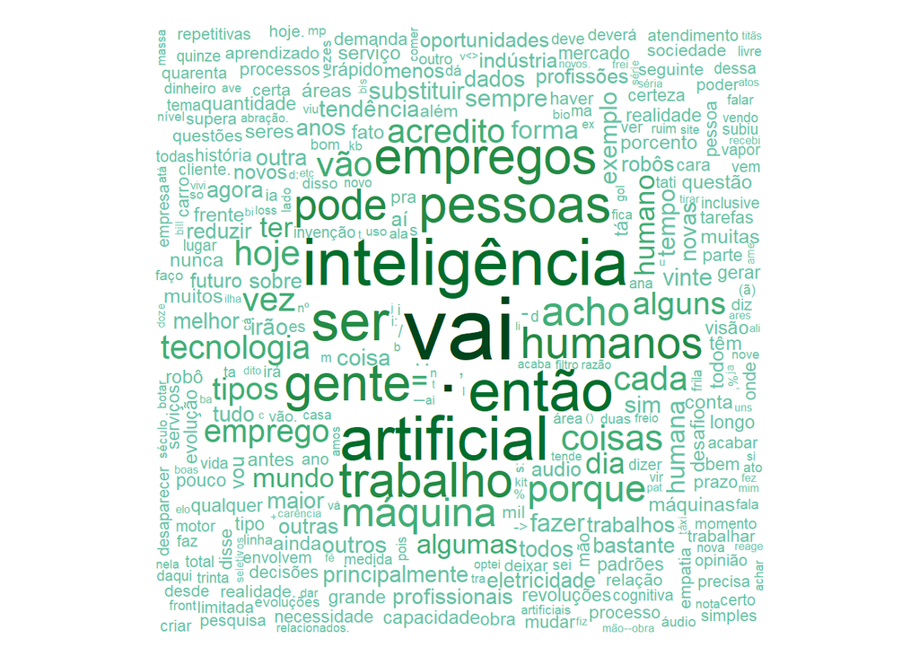

```r
m <- as.matrix(tdm)
word.freq <- sort(rowSums(m), decreasing = T)
pal <- brewer.pal(9, "BuGn")
pal <- pal[-(1:4)]

library(wordcloud)
wordcloud(words = names(word.freq), freq = word.freq, min.freq = 2,
          random.order = F, colors = pal)
```

Neste momento estamos repetindo o processo de retirada e plotagem da base levando em configuração as informações que conseguimos através dos processos anteriores.

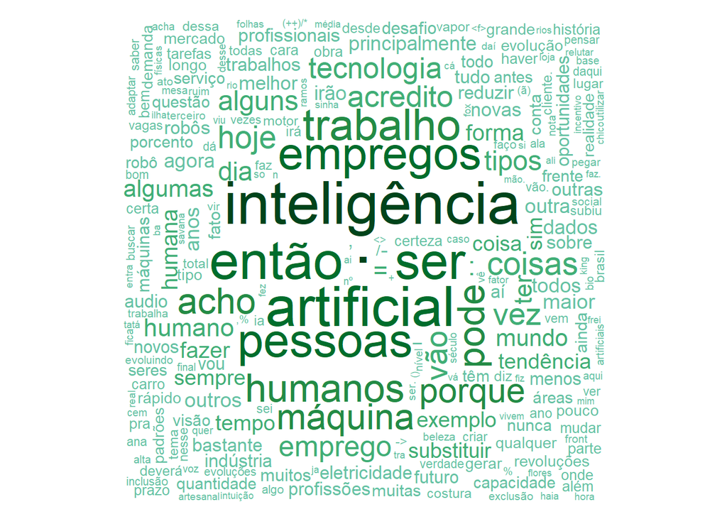

```r
cps <- tm_map(cps, removeWords, c(
                                  #More stop words
                                  "wer", '-', '"', 'wav', 'flac', 'mp3', 'tão', 'é', 'né', "lá", "dois", "seis", "cinco", "boa", "vai", 'ta', 'gente','vinte', 'tá', 'cada', 'gol', 'kb', 'tati', 'bi', 'ma', 'mil', 'tal', 'kit', 'ex', 'd', 't', 'i', 'c', 'l', 'j', 's', 'li', 'es', 'mp', 'u', 'b', 'm', 'rua'))

tdm <- TermDocumentMatrix(cps,
                          control = list(wordLengths = c(1, Inf)))

m <- as.matrix(tdm)
word.freq <- sort(rowSums(m), decreasing = T)
pal <- brewer.pal(9, "BuGn")
pal <- pal[-(1:4)]

library(wordcloud)
wordcloud(words = names(word.freq), freq = word.freq, min.freq = 2,
          random.order = F, colors = pal)
```

Tabém trabalhamos nesta parte com Clusterização e KMeans para dividir nossa base em grupos diferentes de palavras, mais uma vez, estas técnicas nos ajudar a retirar ‘insights’ para melhorar a nossa resposta.

```r
tdm2 <- removeSparseTerms(tdm, sparse = 0.90)
m2 <- as.matrix(tdm2)
distMatrix <- dist(scale(m2))
fit <- hclust(distMatrix, method = "ward.D2")

m3 <- t(m2)
k <- 6
kmeansResult <- kmeans(m3, k)
round(kmeansResult$centers, digits = 3)
```

```
##       = acredito  anos coisa desafio empregos forma história humana mudar
## 1 0.140    0.520 0.020 0.100   0.060    0.480 0.200    0.000  0.040 0.020
## 2 1.000    0.000 0.000 0.000   0.000    0.000 0.000    0.000  0.000 0.000
## 3 1.600    0.200 0.600 1.000   0.200    1.200 0.000    0.000  0.500 0.000
## 4 0.444    1.111 1.111 1.111   1.111    3.222 1.111    1.222  1.111 1.111
## 5 0.000    1.333 0.333 0.000   0.000    0.667 0.000    0.000  0.000 0.000
## 6 0.000    0.154 0.538 0.077   0.231    0.769 0.769    0.154  0.923 0.154
##   mundo máquina outra porcento qualquer rápido sempre  acho algumas
## 1 0.160   0.200 0.060    0.120    0.020  0.000  0.200 0.360   0.380
## 2 0.000   2.500 0.000    0.000    0.000  0.000  0.250 2.750   0.000
## 3 0.400   0.500 0.600    0.000    0.000  0.000  0.000 0.700   0.800
## 4 1.111   1.111 1.111    1.000    1.111  1.111  1.111 0.222   0.000
## 5 0.333   0.000 0.000    0.000    0.333  0.000  0.333 2.000   0.000
## 6 0.692   0.923 0.385    0.154    0.231  0.385  0.308 0.231   0.385
##   artificial coisas inteligência nunca  pode porque profissões quantidade
```

[output cut: 76 more lines]

```r
for (i in 1:k) {
cat(paste("cluster ", i, ": ", sep = ""))
s <- sort(kmeansResult$centers[i, ], decreasing = T)
cat(names(s)[1:10], "\n")
}
```

```
## cluster 1: . ser inteligência artificial então acredito empregos pessoas vez coisas
## cluster 2: tipos trabalho acho alguns então máquina pode porque demanda fato
## cluster 3: inteligência artificial pessoas . tecnologia ter coisas pode = então
## cluster 4: empregos história acredito anos coisa desafio forma humana mudar mundo
## cluster 5: . então humanos vez emprego inteligência pode porque ser robô
## cluster 6: humanos substituir ser trabalho humano porque alguns melhor menos vez
```

Com todos estes dados podemos enfim concluir a nossa análise.

Analizando todos os textos podemos formular um resumo geral sobre todo o conteúdo disponível:

“A inteligência Artificial vai roubar o emprego e os humanos vão adaptar a forma de trabalho”